# Censoring Schemes and Beyond

Ayon Ganguly

Department of Mathematics  
Indian Institute of Technology Guwahati

Jan 28, 2026

# Life Tests

## Life Tests

- $n$ : Number of items put on the test.
- The failure times are recorded chronologically.

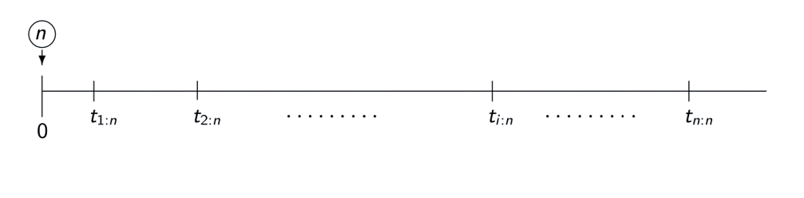

- $t_{1:n} < t_{2:n} < \ldots < t_{n:n}$ are called lifetime or survival times.

## Lifetime or Survival Time

- Lifetime: The time to the occurrence of some event of interest from a particular starting point.
- Sometimes the events are actual deaths of individuals.
- In other instances ``lifetime’’ is used in a figurative sense.

## Example 1

- Manufactured items are often subjected to life tests in order to obtain information on their durability.
- This involves putting items in operation, often in a laboratory setting.
- Observing them until they fail.

## Example 1 (Continued)

- 20 sensors are installed.
- The failure times (in years) of the sensors are as follows:

  0.376, 0.510, 0.513, 0.560, 0.563, 0.573, 0.688, 0.702, 0.717, 0.751, 0.987, 1.100, 1.122, 1.162, 1.354, 1.361, 1.477, 1.580, 1.618, 1.675.

## Example 2

- Demographers and social scientists are interested in the duration of certain life “states” of humans.
- For example, the marriages formed during the year 2020 in Tripura.
- The lifetime of a marriage would be its duration.
- A marriage may end due to annulment, divorce, or death.

## Example 3

- Consider medical studies dealing with potentially fatal diseases.
- Interested in the survival time of individuals with the disease, measured from the date of diagnosis
- To compare treatments for a disease at least partly in terms of the survival time distributions

## Example 4

- Laboratory animals are subjected to doses of carcinogenic substance.
- Observed to see if they develop tumors.
- A main variable of interest is the time to appearance of a tumor, measured from when the dose is administered.

## Example 5

# Censoring

## Censoring

- Quite useful technique in reliability life testing.
- Possible termination of experiment before failing all the experimental units.

## Type-I Censoring

- $n$: Number of items put on the test.
- $\tau$: Pre-fixed time.
- $\tau^* = \tau$: Experiment termination time.

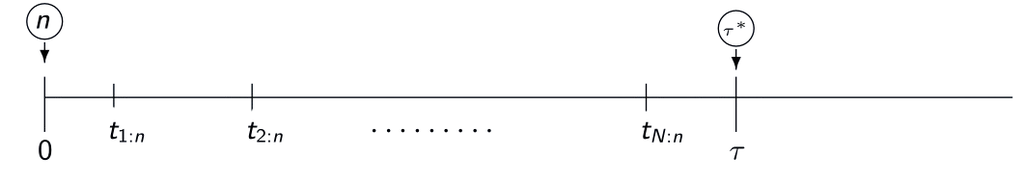

- **Advantage**: Pre-fixed experiment termination time.
- **Disadvantage**: Very few failures, even no failure.

## Type-II Censoring

- $n$: Number of items put on the test.
- $r (\le n)$: Pre-fixed integer.
- $\tau^* = t_{r:n}$: Experiment termination time.

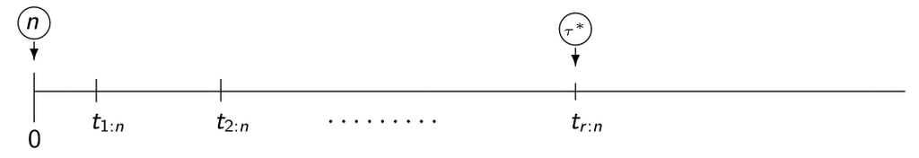

- **Advantage**: Pre-fixed number of failures.
- **Disadvantage**: Long experimental duration.

## Different Censoring Schemes

### Basic Censoring Schemes

- Type-I
- Type-II

### Other Censoring Schemes

- Hybrid Type-I
- Hybrid Type-II
- Progressive Type-II

## Advantages of Censoring

- Lower cost in terms of money and time than complete experiment.
- Survival experimental units can be used for further experiments.

## Average Lifetime

- 20 sensors were installed and monitored until failure.
- Observed Failure Times (in years):

0.376, 0.510, 0.513, 0.560, 0.563, 0.573, 0.688,  
0.702, 0.717, 0.751, 0.987, 1.100, 1.122, 1.162,  
1.354, 1.361, 1.477, 1.580, 1.618, 1.675.

- An estimate of average lifetime: 0.969 years.

## Statistical Challenge (Type-I Example)

- Experiment terminated at the end of 1st year ($\tau^* = 1$).
- Observed failure times:

0.376, 0.510, 0.513, 0.560, 0.563, 0.573, 0.688,  
0.702, 0.717, 0.751, 0.987

- The mean of the observed data: 0.630 years

## Improved Estimate

- Missing out information: 9 sensors lasts more than 1 year.
- An improve estimate of average lifetime:
  $$\frac{\text{Sum of observed lifetimes} + (9\times 1)}{20}=0.797 \text{ years}$$
- If $\tau^*=1.4$ years, improved estimate of average lifetime:
  $$\frac{\text{Sum of observed lifetimes} + (4\times 1.4)}{20}=0.932 \text{ years}$$

## Modelling (Weibull Example)

- Assume lifetimes $T_1,\, T_2,\, \ldots,\, T_{20} \overset{i.i.d.}{\sim} \text{Weibull}(\alpha, \theta)$.
- The PDF is given by
  $$f(x) = \frac{\alpha}{\theta} x^{\alpha-1} e^{-\frac{x^\alpha}{\theta}}\quad \text{for } x > 0.$$

## Likelihood Estimation

Likelihood function of $(\alpha, \theta)$ based on the censored sample is:

$$L(\alpha, \theta) = \frac{n!}{(n-r)!} \left[ \prod_{i=1}^{r} f(t_{i:n}; \alpha, \theta) \right] [1 - F(\tau^*; \alpha, \theta)]^{n-r}$$

- Maximize likelihood function w.r.t. parameters.
- Maximizers of likelihood function are estimates of the respective parameters.

## Revisit Data

- Based on complete sample:
  - $\hat{\alpha}=2.55,\hat{\theta}=1.27,\hat{\mu}=0.975$.
- Ignoring censoring effect:
  - $\hat{\alpha}=4.21,\hat{\theta}=0.21,\hat{\mu}=0.627$.
- Considering censoring effect:
  - $\hat{\alpha}=2.57,\hat{\theta}=1.16,\hat{\mu}=0.941$.

# Competing Risks

## Malignant Melanoma Cancer Data Set

- Melanoma : Skin cancer
- Collected at Odense University Hospital during 1962 to 1977
- Two hundred and five patients
- No of days after the operation
  - until they died
    - until they left the study
    - until the termination of the study in the year 1977

## Malignant Melanoma Cancer Data Set

| no | status | days | ulc | thick | sex |
| --- | --- | --- | --- | --- | --- |
| 789 | 3 | 10 | 1 | 676 | 1 |
| 13 | 3 | 30 | 0 | 65 | 1 |
| 97 | 2 | 35 | 0 | 134 | 1 |
| 16 | 3 | 99 | 0 | 290 | 0 |
| 21 | 1 | 185 | 1 | 1208 | 1 |
| 469 | 1 | 204 | 1 | 484 | 1 |

- no : Patient code
- status : Survival status (1: dead from melanoma, 2: alive, 3: dead from other cause)
- days : Survival time (in days)
- ulc : Ulceration (1: present, 0: absent)
- thick : Tumour thickness (in 1/100 mm)
- sex : Gender (0: female, 1: male)

## Potential Questions

- What is average lifetime for patients dead due to melanoma?
- How does ulcer effects the survival chance of a patient?
- Does gender has effect on survival chance?

## What are Competing Risks?

- Competing Risk is an event whose occurrence precludes the occurrence of the primary event of interest.
- Mutual Exclusivity

## Points to Keep in Mind

- Cannot seperate cause of deaths (competing risks).
- Presence of censored observations.
- Information on covariates.

# Load-sharing Systems

## Two Motor Data (Snippet)

| System | Motor A Failure | Motor B Failure | Event description |
| --- | --- | --- | --- |
| 1 | 102 | 65 | B failed first |
| 2 | 84 | 148 | A failed first |
| 4 | 156 | 121 | B failed first |
| 6 | 139 | 150 | A failed first |
| 10 | 207 | 214 | A failed first |

## What is a Load-Sharing System?

- Components are connected in parallel and share a common workload.
- If one component fails, the remaining components bear the additional load.
- This typically leads to an increased failure rate.

# More Examples

- Cables in a suspension bridge
- Central processing unit of a multiprocessor computer
- Valves or pumps in a hydraulic system
- Generators in a power plant
- Kidneys in the human body
- Eyes in human

## Points to Consider

- Load redistribution rule (Equal Load-Sharing Rule, Spatial/Proximity Effect).
- Dependence between lifetimes of different components.
- Presence of censoring.
- Information on covariates.